# Project 2

## Question 1:

```r
bank_full <- read.csv(file = '/Users/victortu/Desktop/ BUS 461/BUS-461A/Csv files/bank-full.csv', sep = ";" )
summary(bank_full)
```

```
##       age            job              marital           education
##  Min.   :18.00   Length:45211       Length:45211       Length:45211
##  1st Qu.:33.00   Class :character   Class :character   Class :character
##  Median :39.00   Mode  :character   Mode  :character   Mode  :character
##  Mean   :40.94
##  3rd Qu.:48.00
##  Max.   :95.00
##    default             balance         housing              loan
##  Length:45211       Min.   : -8019   Length:45211       Length:45211
##  Class :character   1st Qu.:    72   Class :character   Class :character
##  Mode  :character   Median :   448   Mode  :character   Mode  :character
##                     Mean   :  1362
##                     3rd Qu.:  1428
##                     Max.   :102127
##    contact               day           month              duration
##  Length:45211       Min.   : 1.00   Length:45211       Min.   :   0.0
##  Class :character   1st Qu.: 8.00   Class :character   1st Qu.: 103.0
##  Mode  :character   Median :16.00   Mode  :character   Median : 180.0
##                     Mean   :15.81                      Mean   : 258.2
##                     3rd Qu.:21.00                      3rd Qu.: 319.0
##                     Max.   :31.00                      Max.   :4918.0
##     campaign          pdays          previous          poutcome
##  Min.   : 1.000   Min.   : -1.0   Min.   :  0.0000   Length:45211
##  1st Qu.: 1.000   1st Qu.: -1.0   1st Qu.:  0.0000   Class :character
##  Median : 2.000   Median : -1.0   Median :  0.0000   Mode  :character
##  Mean   : 2.764   Mean   : 40.2   Mean   :  0.5803
##  3rd Qu.: 3.000   3rd Qu.: -1.0   3rd Qu.:  0.0000
##  Max.   :63.000   Max.   :871.0   Max.   :275.0000
##       y
##  Length:45211
##  Class :character
##  Mode  :character
##
##
##
```

After looking at the output for summary(bank_full) it looks like the summary function gives us very useful and quick insight into our dataset.  
Key takeaways:  
-For columns that are numerical, we get statistics on them such as the min, 1st quartile, median, mean, 3rd quartile, and max. These are extremely useful statistics for when we need to make quick analyses of the columns in the dataset.  
-For columns that are categorical, we get the length, class, and mode of the data in the column.

## Question 2:

```r
summary(bank_full$campaign)
```

```
##    Min. 1st Qu.  Median    Mean 3rd Qu.    Max.
##   1.000   1.000   2.000   2.764   3.000  63.000
```

After looking at the summary of the “campaign” column of bank_full, I noticed that the max amount of campaigns in the dataset is 63.000, which seems pretty large. This could be an outlier because the mean and median of the entire “campaign” column is 2.764 and 2.000, respectively. The mean and median values look accurate when compared to the min, 1st quartile, and 3rd quartile values. We have a right or positive skew of values in the “campaign” column.

## Question 3:

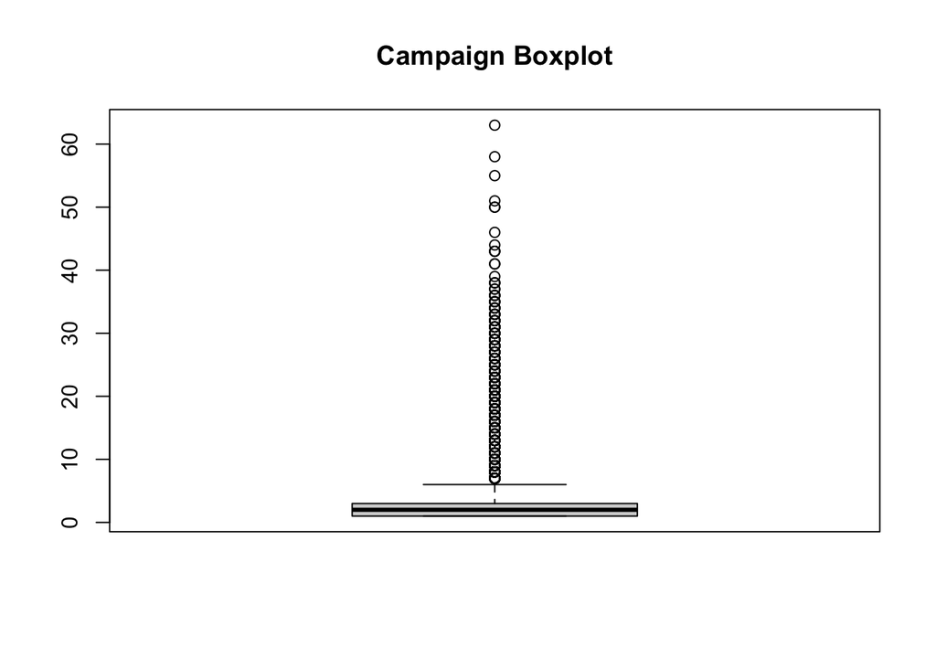

```r
boxplot(bank_full$campaign, main = "Campaign Boxplot")
```

## Question 4:

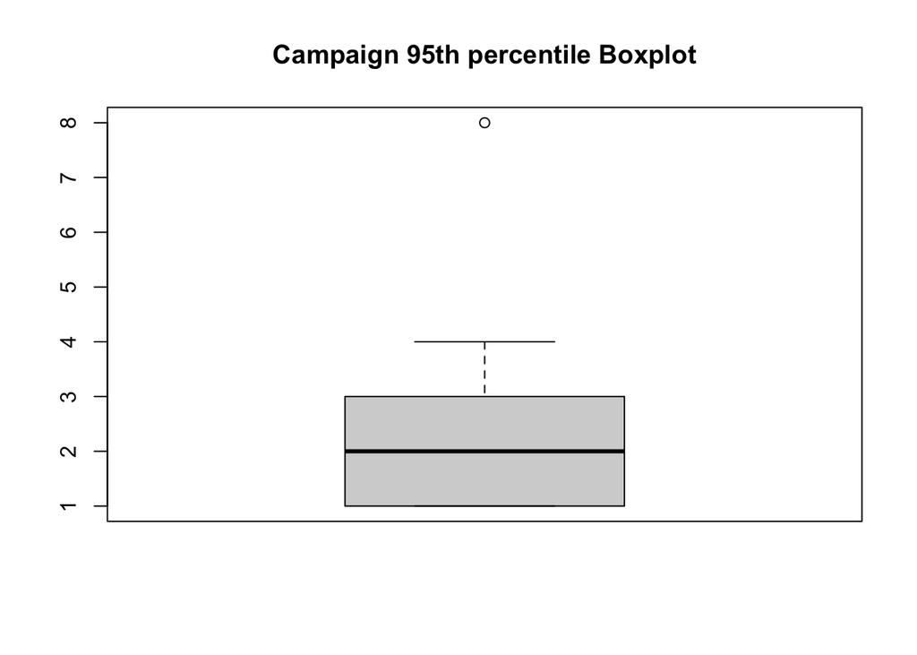

```r
per95 <- quantile(bank_full$campaign, + c(0.1,0.2,0.3,0.4,0.5,0.6,0.75,0.85,0.95))
boxplot(per95, main = "Campaign 95th percentile Boxplot")
```

The above boxplot represents the 95th percentile values of the “campaign” column. This box represents the same min, but it now represents a different quartile 1, 2, median, and quartile 3 (becuase we only have the 95th percentile of “campaign” values). Now there is only one outlier in the boxplot (8).The solid horizontal line in the boxplot represents the median of the 95th percentile of “campaign” values.

## Question 5:

Part 1:

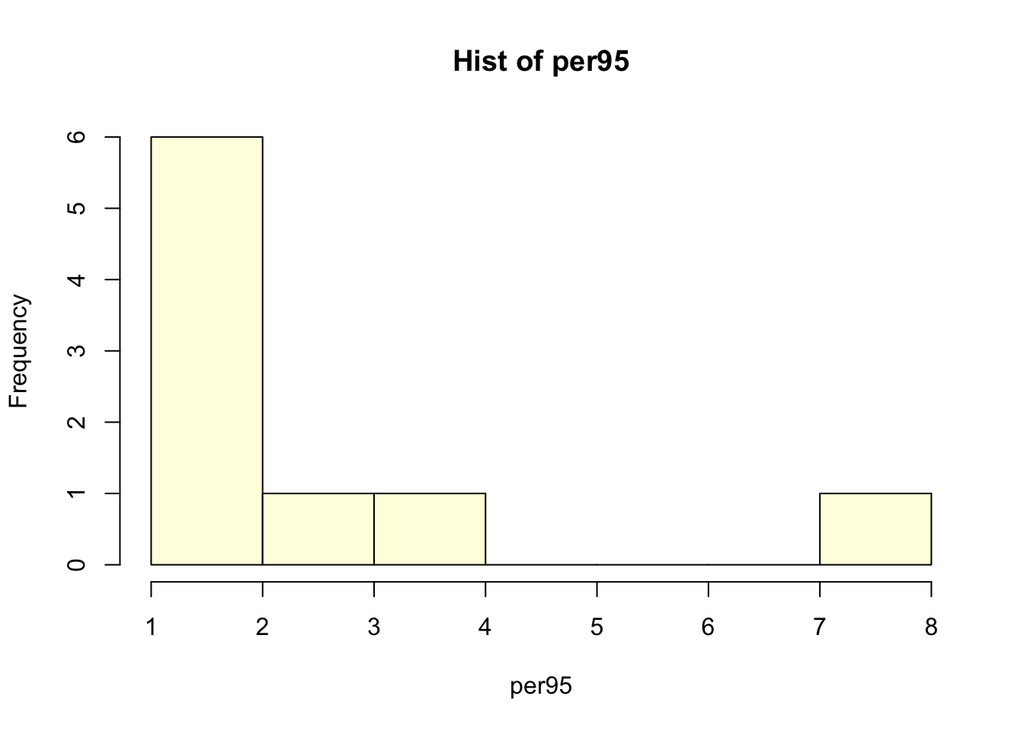

```r
hist(per95, col = "lightyellow", main = "Hist of per95")
```

Part 2:

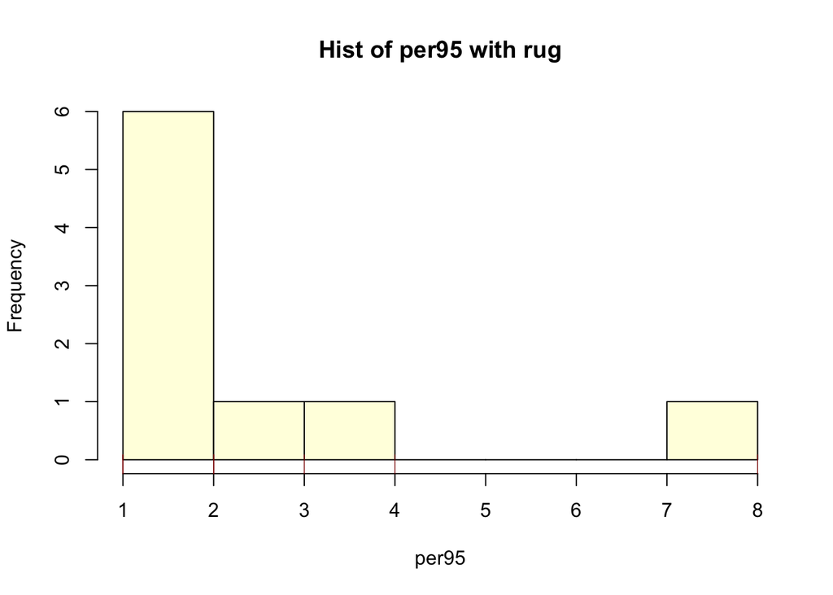

```r
hist(per95, col = "lightyellow",  main = "Hist of per95 with rug")
rug(per95, col = "darkred", ticksize = ".05", lwd = "0.7")
```

The histogram above is with the rug function applied. The rug function allows us to create a set of tick marks along the base of the plot (these tick marks are in dark red). These tick marks allow us to know exact values.

## Question 6:

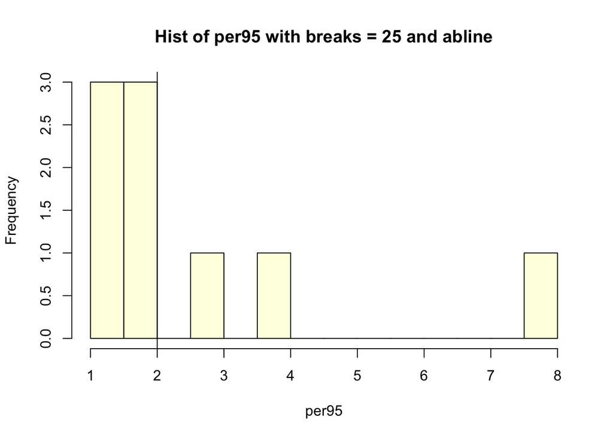

```r
hist(per95, col = "lightyellow", breaks = 25, main = "Hist of per95 with breaks = 25 and abline")
abline(v = median(bank_full$campaign))
```

## Question 7:

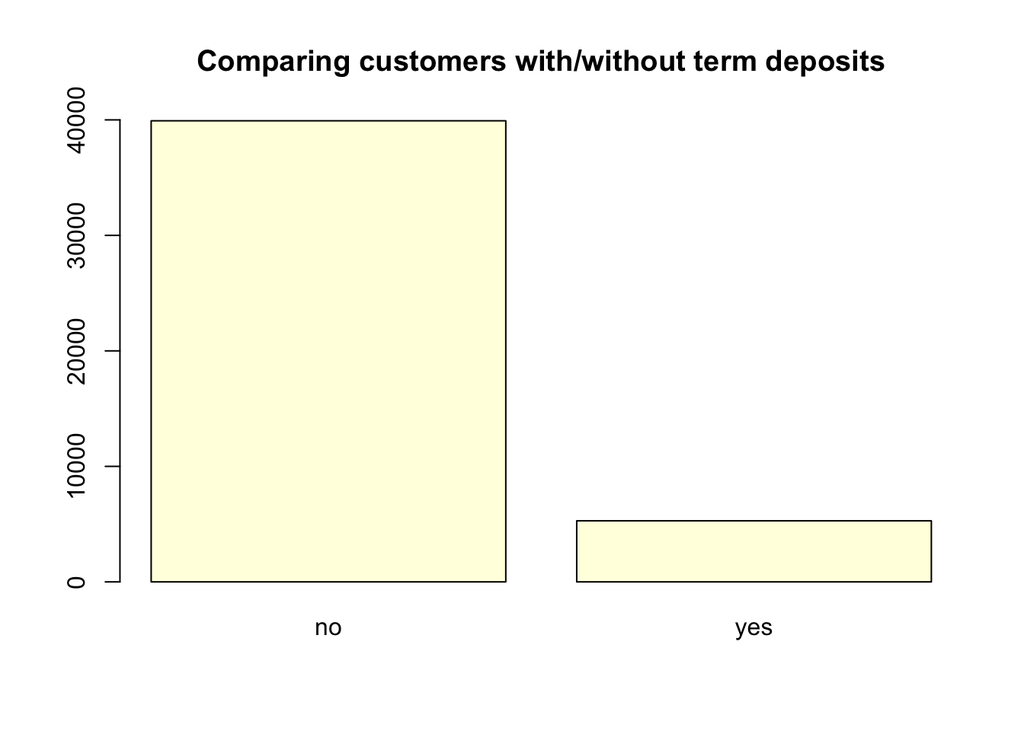

```r
graphCountDeposits <- table(bank_full$y)
barplot(graphCountDeposits, col = "lightyellow", main = "Comparing customers with/without term deposits", ylim = c(0,40000))
```

## Question 8:

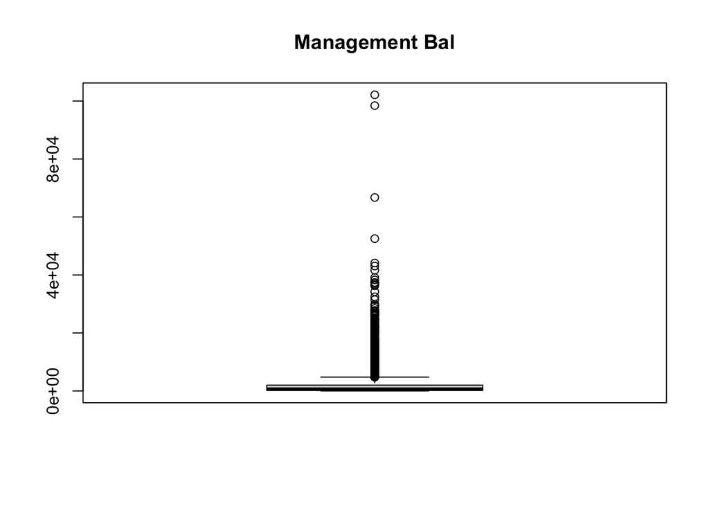

```r
dfmanagement <- subset(bank_full, job == "management" & balance >= "0")
dfstudent <- subset(bank_full, job == "student" & balance >= "0")

boxplot(dfmanagement$balance, main = "Management Bal")
```

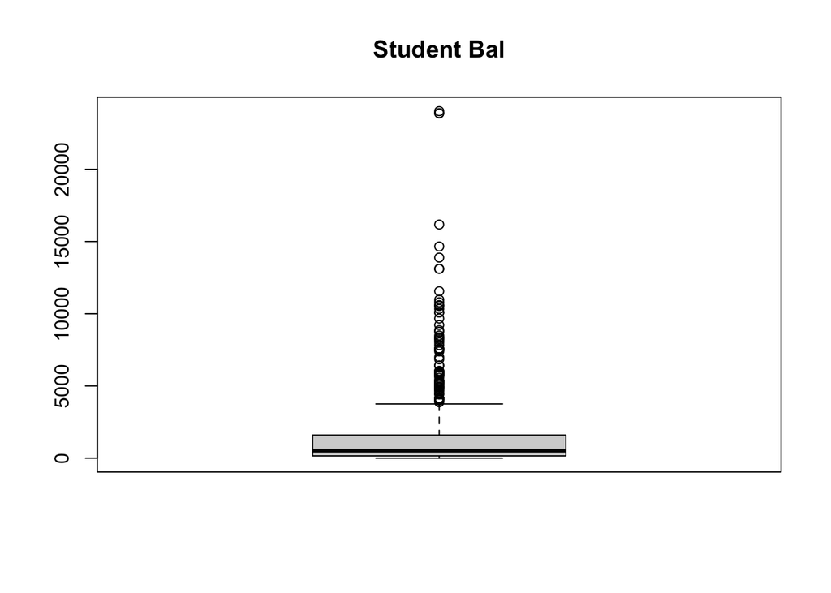

```r
boxplot(dfstudent$balance, main = "Student Bal")
```

From the boxplots for managmement balance and student balance, we can see that the balance of a management, on average, is larger than students. Both box plots have outliers and follow the same trends.